# Case Study: Customer Analytics

# Advanced linear classifiers

We have many predictors, hence we can use regularized LDA or penalized logistic regression

```r
ctrl <- trainControl(method = "cv", number = 5,
                     classProbs = TRUE,
                     verboseIter=T)

# We have many predictors, hence use penalized logistic regression
rdaFit <- train(Churn ~ .,
               method = "rda",
               tuneGrid = expand.grid(gamma = seq(0, 1, 0.2), lambda = seq(0, 1, .2)),
               metric = "Kappa",
               data = training,
               preProcess = c("center", "scale"),
               trControl = ctrl)
print(rdaFit)
```

```
## Regularized Discriminant Analysis
##
## 4924 samples
##   18 predictor
##    2 classes: 'No', 'Yes'
##
## Pre-processing: centered (22), scaled (22)
## Resampling: Cross-Validated (5 fold)
## Summary of sample sizes: 3939, 3939, 3939, 3939, 3940
## Resampling results across tuning parameters:
##
##   gamma  lambda  Accuracy   Kappa
##   0.0    0.0     0.7528420  0.4428174
##   0.0    0.2     0.7619824  0.4501574
##   0.0    0.4     0.7694965  0.4545382
##   0.0    0.6     0.7798520  0.4645587
##   0.0    0.8     0.7859451  0.4599994
##   0.0    1.0     0.7971138  0.4577810
##   0.2    0.0     0.7506085  0.4413516
##   0.2    0.2     0.7607631  0.4534494
##   0.2    0.4     0.7670575  0.4555695
##   0.2    0.6     0.7741662  0.4562333
##   0.2    0.8     0.7847260  0.4612889
##   0.2    1.0     0.7924438  0.4541069
##   0.4    0.0     0.7562954  0.4476578
##   0.4    0.2     0.7634025  0.4540119
##   0.4    0.4     0.7684784  0.4559707
##   0.4    0.6     0.7733527  0.4542543
##   0.4    0.8     0.7847254  0.4654395
##   0.4    1.0     0.7847268  0.4440997
##   0.6    0.0     0.7603551  0.4488596
##   0.6    0.2     0.7644165  0.4519647
##   0.6    0.4     0.7698997  0.4554613
##   0.6    0.6     0.7751795  0.4574148
##   0.6    0.8     0.7798516  0.4576197
##   0.6    1.0     0.7845235  0.4537139
##   0.8    0.0     0.7650248  0.4507389
##   0.8    0.2     0.7668534  0.4497852
##   0.8    0.4     0.7703062  0.4516416
##   0.8    0.6     0.7747745  0.4551933
##   0.8    0.8     0.7770086  0.4551747
##   0.8    1.0     0.7806649  0.4568063
##   1.0    0.0     0.7656349  0.4344731
##   1.0    0.2     0.7652293  0.4366324
##   1.0    0.4     0.7660418  0.4385850
##   1.0    0.6     0.7662451  0.4379480
##   1.0    0.8     0.7670579  0.4394786
##   1.0    1.0     0.7670577  0.4387489
##
## Kappa was used to select the optimal model using the largest value.
## The final values used for the model were gamma = 0.4 and lambda = 0.8.
```

```r
rdaPred = predict(rdaFit, testing)
confusionMatrix(rdaPred, testing$Churn)
```

```
## Confusion Matrix and Statistics
##
##           Reference
## Prediction   No  Yes
##        No  1319  178
##        Yes  229  382
##
##                Accuracy : 0.8069
##                  95% CI : (0.7894, 0.8236)
##     No Information Rate : 0.7343
##     P-Value [Acc > NIR] : 3.869e-15
##
##                   Kappa : 0.5191
##
##  Mcnemar's Test P-Value : 0.0132
##
##             Sensitivity : 0.8521
##             Specificity : 0.6821
##          Pos Pred Value : 0.8811
##          Neg Pred Value : 0.6252
##              Prevalence : 0.7343
##          Detection Rate : 0.6257
##    Detection Prevalence : 0.7102
##       Balanced Accuracy : 0.7671
##
##        'Positive' Class : No
##
```

```r
# We have many predictors, hence use penalized logistic regression
lrFit <- train(Churn ~ .,
               method = "glmnet",
               tuneGrid = expand.grid(alpha = seq(0, 1, 0.1), lambda = seq(0, .1, 0.02)),
               metric = "Kappa",
               data = training,
               preProcess = c("center", "scale"),
               trControl = ctrl)
print(lrFit)
```

```
## glmnet
##
## 4924 samples
##   18 predictor
##    2 classes: 'No', 'Yes'
##
## Pre-processing: centered (22), scaled (22)
## Resampling: Cross-Validated (5 fold)
## Summary of sample sizes: 3940, 3939, 3939, 3939, 3939
## Resampling results across tuning parameters:
##
##   alpha  lambda  Accuracy   Kappa
##   0.0    0.00    0.7956933  0.4399329
##   0.0    0.02    0.7967083  0.4403020
##   0.0    0.04    0.7928499  0.4175558
##   0.0    0.06    0.7926470  0.4087088
##   0.0    0.08    0.7900066  0.3918279
##   0.0    0.10    0.7893981  0.3817777
##   0.1    0.00    0.7944753  0.4440620
##   0.1    0.02    0.7960988  0.4354515
##   0.1    0.04    0.7934598  0.4148323
##   0.1    0.06    0.7916322  0.3960930
##   0.1    0.08    0.7881794  0.3708325
##   0.1    0.10    0.7855386  0.3492871
##   0.2    0.00    0.7944753  0.4443534
##   0.2    0.02    0.7981301  0.4378981
##   0.2    0.04    0.7928505  0.4057816
##   0.2    0.06    0.7887898  0.3756550
##   0.2    0.08    0.7865542  0.3495857
##   0.2    0.10    0.7796498  0.3058329
##   0.3    0.00    0.7942722  0.4439555
##   0.3    0.02    0.7969106  0.4317060
##   0.3    0.04    0.7934609  0.4003019
##   0.3    0.06    0.7875707  0.3605972
##   0.3    0.08    0.7772131  0.2999137
##   0.3    0.10    0.7757920  0.2756696
##   0.4    0.00    0.7944753  0.4443596
##   0.4    0.02    0.7963014  0.4271809
##   0.4    0.04    0.7922418  0.3902128
##   0.4    0.06    0.7810718  0.3275189
```

[output cut: 26 more lines]

```
##   0.9    0.00    0.7944753  0.4443909
##   0.9    0.02    0.7936625  0.4050304
##   0.9    0.04    0.7839161  0.3405633
##   0.9    0.06    0.7674661  0.2285825
##   0.9    0.08    0.7341593  0.0000000
##   0.9    0.10    0.7341593  0.0000000
##   1.0    0.00    0.7946783  0.4448068
##   1.0    0.02    0.7940688  0.4042144
##   1.0    0.04    0.7845258  0.3364576
##   1.0    0.06    0.7648265  0.2065055
##   1.0    0.08    0.7341593  0.0000000
##   1.0    0.10    0.7341593  0.0000000
##
## Kappa was used to select the optimal model using the largest value.
## The final values used for the model were alpha = 0.6 and lambda = 0.
```

```r
lrPred = predict(lrFit, testing)
confusionMatrix(lrPred, testing$Churn)
```

```
## Confusion Matrix and Statistics
##
##           Reference
## Prediction   No  Yes
##        No  1399  246
##        Yes  149  314
##
##                Accuracy : 0.8126
##                  95% CI : (0.7953, 0.8291)
##     No Information Rate : 0.7343
##     P-Value [Acc > NIR] : < 2.2e-16
##
##                   Kappa : 0.4916
##
##  Mcnemar's Test P-Value : 1.363e-06
##
##             Sensitivity : 0.9037
##             Specificity : 0.5607
##          Pos Pred Value : 0.8505
##          Neg Pred Value : 0.6782
##              Prevalence : 0.7343
##          Detection Rate : 0.6637
##    Detection Prevalence : 0.7804
##       Balanced Accuracy : 0.7322
##
##        'Positive' Class : No
##
```

Accuracy around 80%, but not the best performance measure here. Why?

Kappa around 0.46, not bad but it should be improved

### Variable importance

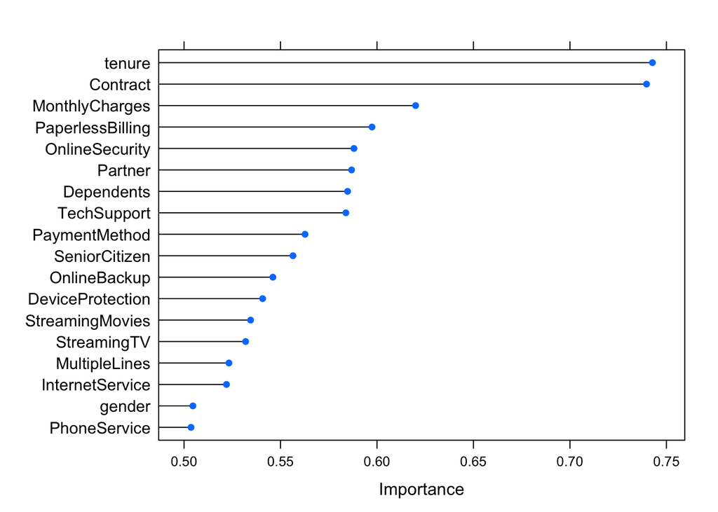

```r
rda_imp <- varImp(rdaFit, scale = F)
plot(rda_imp, scales = list(y = list(cex = .95)))
```

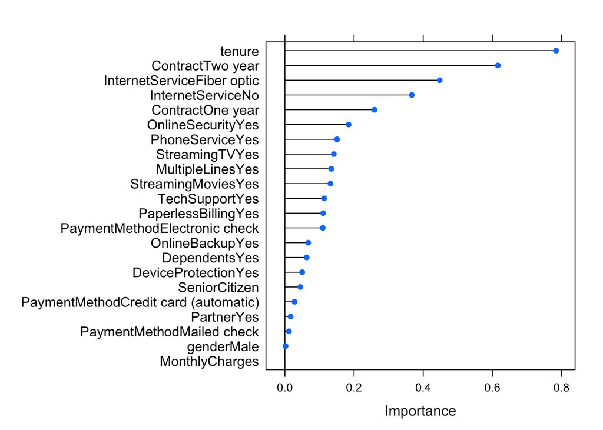

```r
lr_imp <- varImp(lrFit, scale = F)
plot(lr_imp, scales = list(y = list(cex = .95)))
```

### Bayes’ rule

To reduce false negatives, let’s decrease the optimal threshold

```r
threshold = 0.3
rdaProb = predict(rdaFit, testing, type="prob")
rdaPred = rep("No", nrow(testing))
rdaPred[which(rdaProb[,2] > threshold)] = "Yes"
confusionMatrix(factor(rdaPred), testing$Churn)
```

```
## Confusion Matrix and Statistics
##
##           Reference
## Prediction   No  Yes
##        No  1146  112
##        Yes  402  448
##
##                Accuracy : 0.7562
##                  95% CI : (0.7373, 0.7744)
##     No Information Rate : 0.7343
##     P-Value [Acc > NIR] : 0.01191
##
##                   Kappa : 0.4637
##
##  Mcnemar's Test P-Value : < 2e-16
##
##             Sensitivity : 0.7403
##             Specificity : 0.8000
##          Pos Pred Value : 0.9110
##          Neg Pred Value : 0.5271
##              Prevalence : 0.7343
##          Detection Rate : 0.5436
##    Detection Prevalence : 0.5968
##       Balanced Accuracy : 0.7702
##
##        'Positive' Class : No
##
```

Note the trade-off between false negatives and false positives is much better, but also note accuracy and kappa have been worsened

# Cost-sensitive learning

Features increasing chances of leaving:

- Tenure (especially < 12 Months)
- Internet Service = Fiber Optic
- Payment Method = Electronic Check

Features decreasing chances of leaving:

- Contract = two ear
- Total/monthly charges

Accuracy is ok, around 80%. But are the two errors equally important?

The company will be concerned with balancing:

- the cost of a customer who is leaving and has not been targeted,
- the cost of inadvertently targeting customers that are not planning to leave

Usually, the first cost (associated with false negatives) is the most dangerous for the company

Hence, how can we reduce that cost (at the expense of increasing the other cost)?

Assume the following (company’s data):

- Cost of true negatives is 0: the model is correctly identified a happy customer, no need to offer discounts
- Cost of false negatives is 500 (customer value): most problematic error, we lose the customer
- Cost of false positives is 100: retention incentive
- Cost of true positives is 140: (1-gamma)*(customer value) + gamma*(retention incentive)

where gamma=probability a custommer accepts the incentive/offer, 0.9 in our case

Cost matrix:

| Prediction/Reference | no | yes |
| --- | --- | --- |
| predicted no | 0 | 500 |
| predicted yes | 100 | 140 |

Unit cost is then:

0*TN + 100*FP + 500*FN + 140*TP

```r
cost.unit <- c(0, 100, 500, 140)
```

### Cost of Naive classifier

Unit cost for Naive classifier (no analytics knowledge)

cost = 0*.74 + 100*0 + 500*.26 + + 140*0 = 130eur/customer on average

Savings = (retention incentive - cost)

in the case of the naive classifier, the savings = -30eur/customer, i.e. a loss

Savings from the regularized LDA (that needs analytics knowledge)

```r
CM = confusionMatrix(factor(rdaPred), testing$Churn)$table
cost = sum(as.vector(CM)*cost.unit)/sum(CM)
cost
```

```
## [1] 75.38899
```

Savings per customer around 20 eur, i.e. 50 eur better than the naive

## Cost-sensitive classifier (expert level)

```r
cost.i = matrix(NA, nrow = 50, ncol = 10)
# 50 replicates for training/testing sets for each of the 10 values of threshold

j <- 0
for (threshold in seq(0.05,0.5,0.05)){

  j <- j + 1
  cat(j)
  for(i in 1:50){

    # partition data intro training (75%) and testing sets (25%)
    d <- createDataPartition(training$Churn, p = 0.8, list = FALSE)
    # select training sample

    train <- churnData[d,]
    test  <- churnData[-d,]

    rdaFit <- train(Churn ~ ., data=train, method = "rda",
                   tuneGrid = data.frame(gamma = 0.2, lambda = 0.6), preProcess = c("center", "scale"),
                   trControl = trainControl(method = "none", classProbs = TRUE))

    rdaProb = predict(rdaFit, test, type="prob")
    rdaPred = rep("No", nrow(test))
    rdaPred[which(rdaProb[,2] > threshold)] = "Yes"

    CM = confusionMatrix(factor(rdaPred), test$Churn)$table
    cost = sum(as.vector(CM)*cost.unit)/sum(CM)
    cost

    cost.i[i,j] <- cost

  }
}
```

```
## 12345678910
```

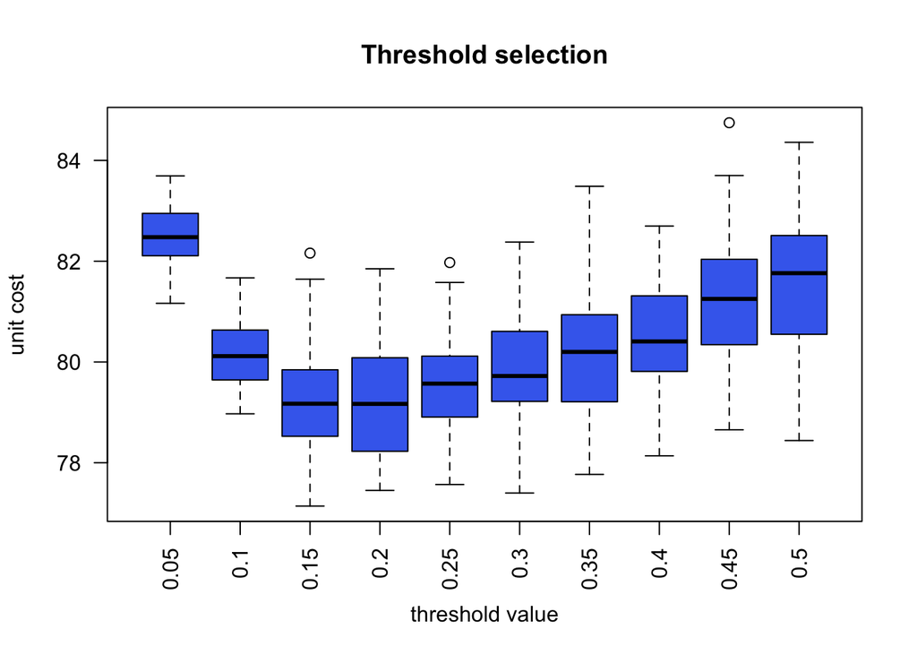

```r
# Threshold optimization:
boxplot(cost.i, main = "Threshold selection",
        ylab = "unit cost",
        xlab = "threshold value",
        names = seq(0.05,0.5,0.05),col="royalblue2",las=2)
```

```r
# values around 0.2 are reasonable
apply(cost.i, 2, median)
```

```
##  [1] 82.47736 80.11643 79.17206 79.16882 79.56986 79.72186 80.20052 80.40750
##  [9] 81.25162 81.76261
```

Savings around 20eur/customer on average

Can you imagine the savings with just 100,000 customers?

Final prediction:

```r
threshold = 0.2
rdaFit <- train(Churn ~ ., data=training, method = "rda",
               tuneGrid = data.frame(gamma = 0.2, lambda = 0.6), preProcess = c("center", "scale"),
               trControl = trainControl(method = "none", classProbs = TRUE))
rdaProb = predict(rdaFit, testing, type="prob")
rdaPred = rep("No", nrow(testing))
rdaPred[which(rdaProb[,2] > threshold)] = "Yes"
CM = confusionMatrix(factor(rdaPred), testing$Churn)$table
cost = sum(as.vector(CM)*cost.unit)/sum(CM)
cost
```

```
## [1] 76.02467
```

# Risk learning

There are customers who provide more income to the company than others

Hence, we should focus on them if their churn probability is high

Predicted probabilities by real churn status

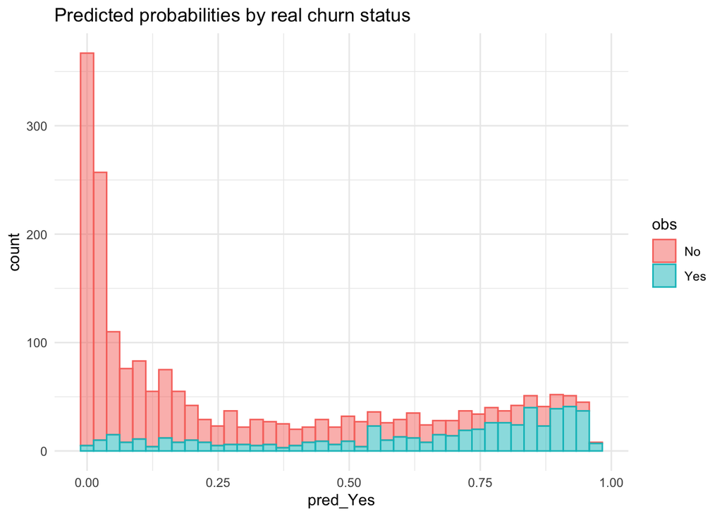

```r
data.frame(pred_Yes = rdaProb[,2], obs=testing$Churn) %>%
  ggplot(aes(x=pred_Yes, fill=obs, color=obs)) +
  geom_histogram(bins=40, alpha=0.5) +
  theme_minimal()+
  labs(title="Predicted probabilities by real churn status")
```

But are all the clients equally important?

Money at risk:

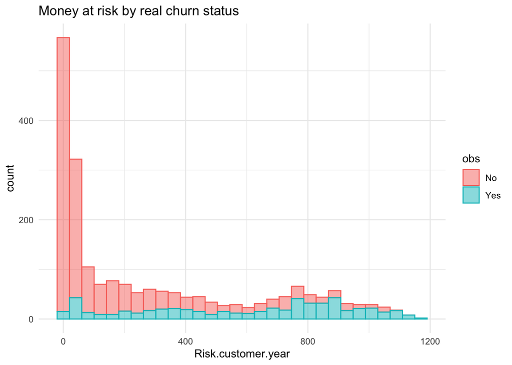

```r
Risk.customer.year = testing$MonthlyCharges*rdaProb[,2]*12
data.frame(Risk.customer.year = Risk.customer.year, obs=testing$Churn) %>%
  ggplot(aes(x=Risk.customer.year, fill=obs, color=obs)) +
  geom_histogram(bins=30, alpha=0.5) +
  theme_minimal()+
  labs(title="Money at risk by real churn status")
```

We should focus on customers with money.at.risk > 700 eur

```r
sum(Risk.customer.year>700)/length(Risk.customer.year)
```

```
## [1] 0.193074
```

Around 20% of customers would incur high losses, but who are they?

```r
sort.risk = sort(Risk.customer.year,decreasing=T,index.return=T)

# Most risky positions:
head(sort.risk$x)
```

```
## [1] 1170.071 1153.160 1136.741 1128.266 1124.759 1124.694
```

```r
# Most risky customers:
head(sort.risk$ix)
```

```
## [1] 1910  937  862 1482 1551  701
```

We can then offer risky customers a discount or better service, etc.

# From caret to tidymodels

**tidymodels:** ecosystem of packages to implement efficient ML workflows

It contains the following packages:

- rsample provides infrastructure for efficient data splitting and resampling
- parsnip is a tidy, unified interface to models independent of the particular package syntax
- recipes is a tidy interface to data pre-processing tools for feature engineering. workflows bundle your pre-processing, modeling, and post-processing together
- tune optimizes the hyperparameters
- yardstick provides model performance metrics
- broom converts the information in common statistical R objects into user-friendly tidy formats
- dials creates and manages tuning parameters and parameter grids.

More powerful but difficult to use than caret

## ML workflows

Standard workflow:

- Split dataset in training & test sample

This is done with the rsample function initial_split()

- Apply preprocessing steps if necessary

Can be done manually, but better by defining a recipe

- Define the models to fit

Done by setting up a model structure with parsnip

- Define a resampling strategy

We choose among diferent resampling options with the rsample package

- Tune Hyperparameters

Here we use the tune package to tune hyperparameters and the dials package to manage the hyperparameter search

- Select the best performing hyperparameter setup

Fit the final model

- Evaluate it on the test data

## The package

```r
library(tidymodels)
```

## Splitting

```r
churnData <- read.csv('ChurnData.csv', stringsAsFactors=T)

data_split <- initial_split(churnData, prop = 0.7, strata = Churn)

training <- data_split  %>%  training()
testing <- data_split %>% testing()
```

## Pre-processing: the recipe

```r
library(themis) # for subsampling

churn_recipe <- training %>%
  recipe(Churn ~ .) %>%
  update_role(customerID, new_role = "ID") %>%
  step_rm(customerID) %>%
  #  step_naomit(all_outcomes(), all_predictors()) %>%
  step_impute_knn(all_predictors()) %>% #  knn inputation of missing values
  step_discretize(tenure, options = list(cuts = 5)) %>%
  step_log(TotalCharges) %>%
  step_nzv(all_numeric(), -all_outcomes()) %>% # removes predictors with near zero variability
  step_dummy(all_nominal(), -all_outcomes()) %>%
  step_interact(terms = ~ TotalCharges:Contract_Two.year + TotalCharges:tenure_bin1) %>% # interactions
  step_lincomb(-all_outcomes()) %>% # removes predictors that are linear combinations of others
  #  step_rose(Churn) %>% # subsampling
  step_normalize(all_numeric(), -all_outcomes())

churn_recipe
```

```
## Recipe
##
## Inputs:
##
##       role #variables
##         ID          1
##    outcome          1
##  predictor         19
##
## Operations:
##
## Delete terms customerID
## K-nearest neighbor imputation for all_predictors()
## Dummy variables from tenure
## Log transformation on TotalCharges
## Sparse, unbalanced variable filter on all_numeric(), -all_outcomes()
## Dummy variables from all_nominal(), -all_outcomes()
## Interactions with TotalCharges:Contract_Two.year + TotalCharges:tenure_bin1
## Linear combination filter on -all_outcomes()
## Centering and scaling for all_numeric(), -all_outcomes()
```

```r
View(juice(prep(churn_recipe)))
```

## The models and engines

LDA in high dimension:

```r
library(discrim)

# klaR
model_lda <-
  discrim_regularized(frac_common_cov = tune(), frac_identity = tune()) %>%
  set_engine('klaR')
```

## The workflow

```r
wfl <- workflow() %>%
  add_model(model_lda) %>%
  add_recipe(churn_recipe)
```

## Resampling and tuning

In this case, 5-fold cross validation

```r
# train-validation splits
cv_splits <- vfold_cv(training, v=5, strata = Churn)
```

Then, tune the hyper-parameters using cross-validation (with training data)

```r
lda_tune <- wfl %>%
  tune_grid(resamples = cv_splits,
         #   grid = expand_grid(frac_common_cov = seq(0.5, 1, by = 0.1), frac_identity = seq(0.1, 5, by = 0.1)),
            grid = 25, # automatic, try 25 values in the grid
            metrics = metric_set(accuracy, kap, roc_auc),
            control = control_grid(save_pred = TRUE, verbose = TRUE))

lda_tune %>%
  collect_metrics()
```

```
## # A tibble: 75 × 8
##    frac_common_cov frac_identity .metric  .estimator  mean     n std_err .config
##              <dbl>         <dbl> <chr>    <chr>      <dbl> <int>   <dbl> <chr>
##  1           0.127        0.565  accuracy binary     0.767     5 0.00538 Prepro…
##  2           0.127        0.565  kap      binary     0.473     5 0.0115  Prepro…
##  3           0.127        0.565  roc_auc  binary     0.846     5 0.00527 Prepro…
##  4           0.409        0.0812 accuracy binary     0.775     5 0.00801 Prepro…
##  5           0.409        0.0812 kap      binary     0.483     5 0.0160  Prepro…
##  6           0.409        0.0812 roc_auc  binary     0.847     5 0.00531 Prepro…
##  7           0.681        0.660  accuracy binary     0.788     5 0.00640 Prepro…
##  8           0.681        0.660  kap      binary     0.490     5 0.0132  Prepro…
##  9           0.681        0.660  roc_auc  binary     0.847     5 0.00594 Prepro…
## 10           0.111        0.912  accuracy binary     0.775     5 0.00714 Prepro…
## # … with 65 more rows
```

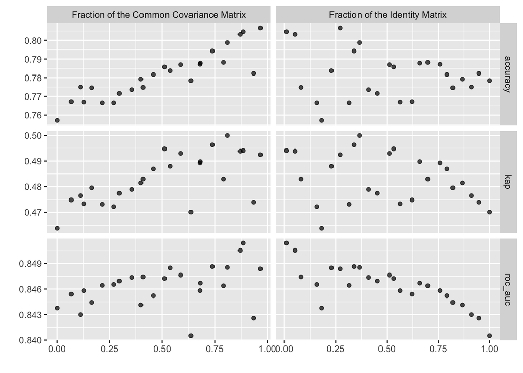

```r
lda_tune %>%
  autoplot()
```

## Select the best model

Choose a performance measure

```r
# best_lda <- select_best(lda_tune, metric = "accuracy")
# best_lda <- select_best(lda_tune, metric = "roc_auc")
best_lda <- select_best(lda_tune, metric = "kap")
```

## The final workflow

```r
wfl_final <-
  wfl %>%
  finalize_workflow(best_lda) %>%
  fit(data = training)

wfl_final %>%
  extract_fit_parsnip()
```

```
## parsnip model object
##
## Fit time:  253ms
## Call:
## rda(formula = ..y ~ ., data = data, lambda = ~0.810169061990455,
##     gamma = ~0.365429672645405)
##
## Regularization parameters:
##     gamma    lambda
## 0.3654297 0.8101691
##
## Prior probabilities of groups:
##        No       Yes
## 0.7346318 0.2653682
##
## Misclassification rate:
##        apparent: 19.984 %
```

## Predictions

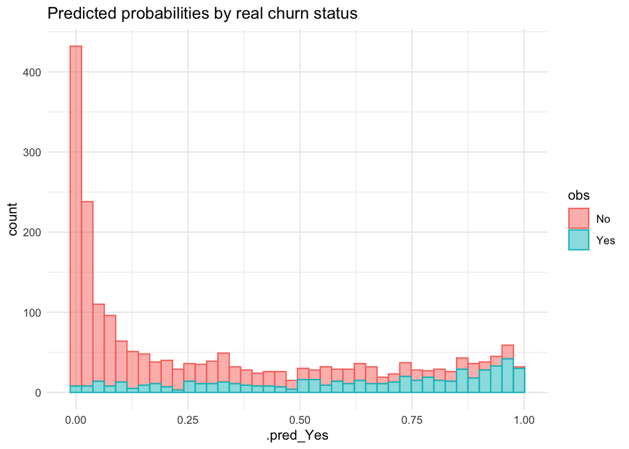

```r
probs <-
  predict(wfl_final, type = "prob", new_data = testing) %>%
  bind_cols(obs = testing$Churn) %>%
  bind_cols(predict(wfl_final, new_data = testing))

probs %>% ggplot(aes(x=.pred_Yes, fill=obs, color=obs)) +
  geom_histogram(bins=40, alpha=0.5) +
  theme_minimal()+
  labs(title="Predicted probabilities by real churn status")
```

## Performance measures

With a probability threshold = 0.50

```r
conf_mat(probs, obs, .pred_class)
```

```
##           Truth
## Prediction   No  Yes
##        No  1278  184
##        Yes  275  377
```

```r
summary(conf_mat(probs, obs, .pred_class))
```

```
## # A tibble: 13 × 3
##    .metric              .estimator .estimate
##    <chr>                <chr>          <dbl>
##  1 accuracy             binary         0.783
##  2 kap                  binary         0.471
##  3 sens                 binary         0.823
##  4 spec                 binary         0.672
##  5 ppv                  binary         0.874
##  6 npv                  binary         0.578
##  7 mcc                  binary         0.473
##  8 j_index              binary         0.495
##  9 bal_accuracy         binary         0.747
## 10 detection_prevalence binary         0.692
## 11 precision            binary         0.874
## 12 recall               binary         0.823
## 13 f_meas               binary         0.848
```

ROC

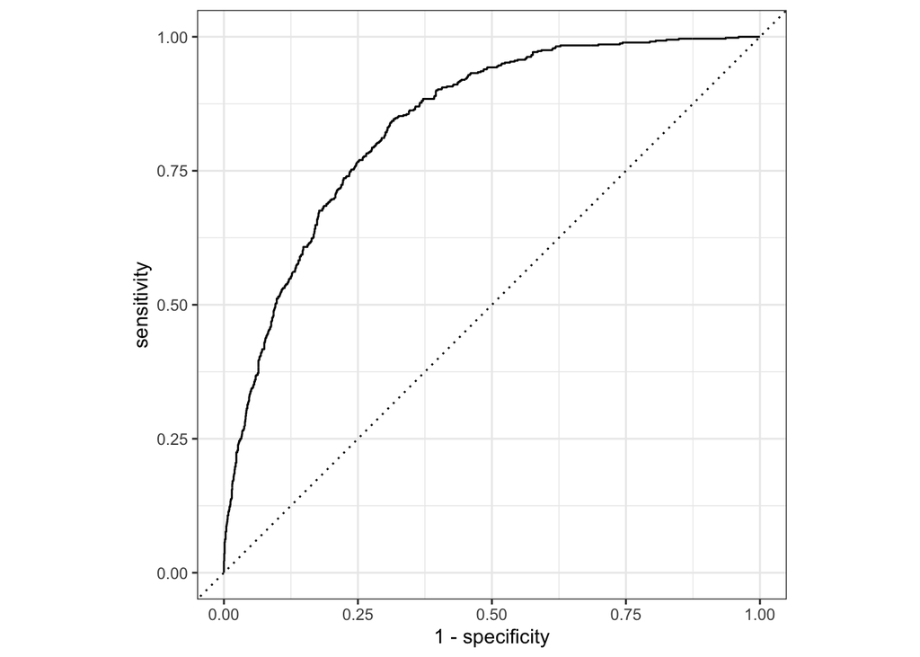

```r
autoplot(roc_curve(probs, obs, .pred_Yes, event_level = "second"))
```

```r
roc_auc(probs, obs, .pred_Yes, event_level = "second")
```

```
## # A tibble: 1 × 3
##   .metric .estimator .estimate
##   <chr>   <chr>          <dbl>
## 1 roc_auc binary         0.839
```

## Probability threshold

```r
library(probably)

# threshold is associated with probabilities of the first level in target
probs %>%
  mutate(.pred = make_two_class_pred(.pred_No, levels(obs), threshold = .7)) %>%
  conf_mat(obs, .pred)
```

```
##           Truth
## Prediction   No  Yes
##        No  1116  115
##        Yes  437  446
```

## Risk learning

```r
probs <- probs %>%
  bind_cols(Risk.customer.year = testing$MonthlyCharges*probs$.pred_Yes*12)
```

Money at risk:

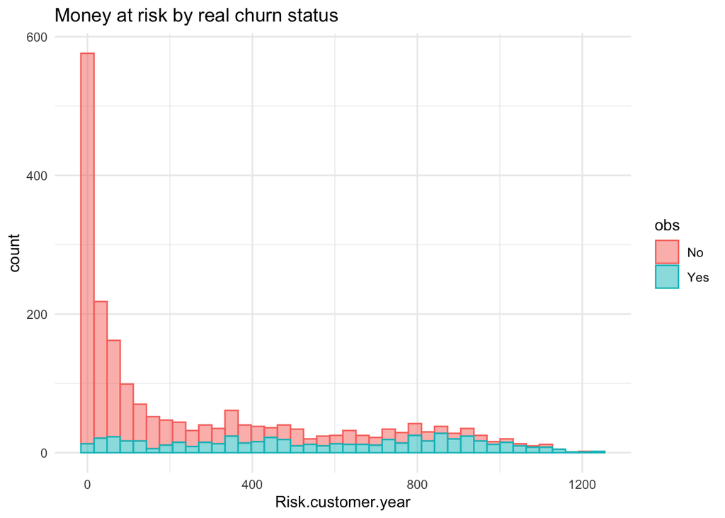

```r
probs %>% ggplot(aes(x=Risk.customer.year, fill=obs, color=obs)) +
  geom_histogram(bins=40, alpha=0.5) +
  theme_minimal()+
  labs(title="Money at risk by real churn status")
```